# Preços de combustível no Brasil

👩🏽‍💻 Eduarda Michaelle

(data: 01/10/2022)

```r
install.packages("tidyverse")
install.packages("summarytools")
install.packages("lubridate")
library(tidyverse)
library(lubridate)
library(summarytools)
```

# Leitura e limpeza de dados

```r
combustivel_info <- read_tsv(
  '2004-2021.tsv'
  )
glimpse(combustivel_info)
```

```
## Rows: 120,823
## Columns: 18
## $ `DATA INICIAL`                  <date> 2004-05-09, 2004-05-09, 2004-05-09, 2…
## $ `DATA FINAL`                    <date> 2004-05-15, 2004-05-15, 2004-05-15, 2…
## $ REGIÃO                          <chr> "CENTRO OESTE", "CENTRO OESTE", "CENTR…
## $ ESTADO                          <chr> "DISTRITO FEDERAL", "GOIAS", "MATO GRO…
## $ PRODUTO                         <chr> "ETANOL HIDRATADO", "ETANOL HIDRATADO"…
## $ `NÚMERO DE POSTOS PESQUISADOS`  <dbl> 127, 387, 192, 162, 103, 408, 278, 105…
## $ `UNIDADE DE MEDIDA`             <chr> "R$/l", "R$/l", "R$/l", "R$/l", "R$/l"…
## $ `PREÇO MÉDIO REVENDA`           <dbl> 1.288, 1.162, 1.389, 1.262, 1.181, 1.3…
## $ `DESVIO PADRÃO REVENDA`         <dbl> 0.016, 0.114, 0.097, 0.070, 0.078, 0.1…
## $ `PREÇO MÍNIMO REVENDA`          <dbl> 1.190, 0.890, 1.180, 1.090, 1.050, 0.9…
## $ `PREÇO MÁXIMO REVENDA`          <dbl> 1.350, 1.449, 1.760, 1.509, 1.400, 2.0…
## $ `MARGEM MÉDIA REVENDA`          <chr> "0.463", "0.399", "0.419", "0.432", "0…
## $ `COEF DE VARIAÇÃO REVENDA`      <dbl> 0.012, 0.098, 0.070, 0.055, 0.066, 0.0…
## $ `PREÇO MÉDIO DISTRIBUIÇÃO`      <chr> "0.825", "0.763", "0.97", "0.83", "0.9…
## $ `DESVIO PADRÃO DISTRIBUIÇÃO`    <chr> "0.11", "0.088", "0.095", "0.119", "0.…
## $ `PREÇO MÍNIMO DISTRIBUIÇÃO`     <chr> "0.4201", "0.5013", "0.5614", "0.5991"…
## $ `PREÇO MÁXIMO DISTRIBUIÇÃO`     <chr> "0.9666", "1.05", "1.161", "1.22242", …
## $ `COEF DE VARIAÇÃO DISTRIBUIÇÃO` <chr> "0.133", "0.115", "0.098", "0.143", "0…
```

- Verificando se há valores faltantes `(NA)`:

```r
# Usando a função any para testar se há pelo menos 1 valor ausente em uma coluna dos dados.
any(is.na(combustivel_info))
```

```
## [1] FALSE
```

# Análise Exploratória

- Verificando a quantidade de combustíveis diferentes analisados:

```r
table(combustivel_info$PRODUTO)
```

```
##
##   ETANOL HIDRATADO GASOLINA ADITIVADA     GASOLINA COMUM                GLP
##              23440                749              23570              23561
##                GNV        OLEO DIESEL        ÓLEO DIESEL    OLEO DIESEL S10
##              14469               2351              21194               2376
##    ÓLEO DIESEL S10
##               9113
```

- Qual o menor preço que cada combustível teve entre todos os anos analisados? E o maior?

```r
combustivel_info %>%
  group_by(PRODUTO) %>%
  summarize(`MENOR PREÇO` = min(`PREÇO MÉDIO REVENDA`)) %>%
  arrange(`MENOR PREÇO`)
```

```
## # A tibble: 9 × 2
##   PRODUTO            `MENOR PREÇO`
##   <chr>                      <dbl>
## 1 ETANOL HIDRATADO           0.766
## 2 GNV                        0.975
## 3 ÓLEO DIESEL                1.31
## 4 GASOLINA COMUM             1.89
## 5 ÓLEO DIESEL S10            2.13
## 6 OLEO DIESEL                2.73
## 7 OLEO DIESEL S10            2.83
## 8 GASOLINA ADITIVADA         3.85
## 9 GLP                       28.0
```

```r
combustivel_info %>%
  group_by(PRODUTO) %>%
  summarize(`MAIOR PREÇO` = max(`PREÇO MÉDIO REVENDA`)) %>%
  arrange(`MAIOR PREÇO`)
```

```
## # A tibble: 9 × 2
##   PRODUTO            `MAIOR PREÇO`
##   <chr>                      <dbl>
## 1 ÓLEO DIESEL                 4.77
## 2 GNV                         4.78
## 3 ÓLEO DIESEL S10             4.88
## 4 OLEO DIESEL                 5.85
## 5 OLEO DIESEL S10             5.86
## 6 ETANOL HIDRATADO            5.96
## 7 GASOLINA ADITIVADA          6.68
## 8 GASOLINA COMUM              6.69
## 9 GLP                       108.
```

- Total de postos pesquisados por todo Brasil (desde 2004):

```r
postos <- combustivel_info['NÚMERO DE POSTOS PESQUISADOS']
sum(postos)
```

```
## [1] 26709913
```

- Média do preço dos combustíveis no Brasil em 2004:

```r
# Inserindo a coluna DATA INICIAL em datas
DATAS <- combustivel_info['DATA INICIAL']
# Inserindo a coluna PREÇO MÉDIO REVENDA em PREÇOS
PREÇOS <- combustivel_info['PREÇO MÉDIO REVENDA']
# Inserindo a coluna PRODUTO em COMBUSTÍVEL
COMBUSTÍVEL <- combustivel_info['PRODUTO']
# Inserindo a coluna ESTADO em EST
EST <- combustivel_info['ESTADO']

# Criando um for para armazenar no vetor ANOS, apenas os anos das datas da tabela DATAS
for (elem in DATAS)
{
  ANOS <- year(elem)
}

# Criando uma tabela com DATAS, PREÇOS e ANOS
tabela <- tibble(DATAS, EST, PREÇOS, COMBUSTÍVEL, ANOS)

# Filtrando as linhas com os anos = 2004 e criando outra tabela apenas com os preços de 2004
anos_2004 <- tabela %>% filter(ANOS==2004) %>%
  arrange(`DATA INICIAL`)

# Imprimindo a tabela com os preços médios de 2004
anos_2004
```

```
## # A tibble: 4,205 × 5
##    `DATA INICIAL` ESTADO             `PREÇO MÉDIO REVENDA` PRODUTO          ANOS
##    <date>         <chr>                              <dbl> <chr>           <dbl>
##  1 2004-05-09     DISTRITO FEDERAL                    1.29 ETANOL HIDRATA…  2004
##  2 2004-05-09     GOIAS                               1.16 ETANOL HIDRATA…  2004
##  3 2004-05-09     MATO GROSSO                         1.39 ETANOL HIDRATA…  2004
##  4 2004-05-09     MATO GROSSO DO SUL                  1.26 ETANOL HIDRATA…  2004
##  5 2004-05-09     ALAGOAS                             1.18 ETANOL HIDRATA…  2004
##  6 2004-05-09     BAHIA                               1.38 ETANOL HIDRATA…  2004
##  7 2004-05-09     CEARA                               1.45 ETANOL HIDRATA…  2004
##  8 2004-05-09     MARANHAO                            1.63 ETANOL HIDRATA…  2004
##  9 2004-05-09     PARAIBA                             1.28 ETANOL HIDRATA…  2004
## 10 2004-05-09     PERNAMBUCO                          1.22 ETANOL HIDRATA…  2004
## # … with 4,195 more rows
```

```r
# Imprimindo a média
anos_2004 %>%
  pull("PREÇO MÉDIO REVENDA") %>%
  mean()
```

```
## [1] 8.35137
```

- Média do preço do combustível no Brasil em 2021:

```r
DATAS <- combustivel_info['DATA INICIAL']
PREÇOS <- combustivel_info['PREÇO MÉDIO REVENDA']
COMBUSTÍVEL <- combustivel_info['PRODUTO']
EST <- combustivel_info['ESTADO']

for (elem in DATAS)
{
  ANOS <- year(elem)
}

tabela <- tibble(DATAS, EST, PREÇOS, COMBUSTÍVEL, ANOS)
anos_2021 <- tabela %>% filter(ANOS==2021)

anos_2021
```

```
## # A tibble: 3,019 × 5
##    `DATA INICIAL` ESTADO           `PREÇO MÉDIO REVENDA` PRODUTO           ANOS
##    <date>         <chr>                            <dbl> <chr>            <dbl>
##  1 2021-01-03     ACRE                              4.04 ETANOL HIDRATADO  2021
##  2 2021-01-03     ALAGOAS                           3.62 ETANOL HIDRATADO  2021
##  3 2021-01-03     AMAZONAS                          3.48 ETANOL HIDRATADO  2021
##  4 2021-01-03     BAHIA                             3.66 ETANOL HIDRATADO  2021
##  5 2021-01-03     CEARA                             3.80 ETANOL HIDRATADO  2021
##  6 2021-01-03     DISTRITO FEDERAL                  3.58 ETANOL HIDRATADO  2021
##  7 2021-01-03     ESPIRITO SANTO                    3.70 ETANOL HIDRATADO  2021
##  8 2021-01-03     GOIAS                             3.30 ETANOL HIDRATADO  2021
##  9 2021-01-03     MARANHAO                          3.83 ETANOL HIDRATADO  2021
## 10 2021-01-03     MATO GROSSO                       3.24 ETANOL HIDRATADO  2021
## # … with 3,009 more rows
```

```r
anos_2021 %>%
  pull("PREÇO MÉDIO REVENDA") %>%
  mean()
```

```
## [1] 16.69207
```

➞ Podemos perceber que em 17 anos o preço médio dos combustíveis dobrou.

- As informações apenas do estado do Rio de Janeiro (2004-2021):

```r
combustivel_info %>%
  filter(ESTADO == 'RIO DE JANEIRO')
```

```
## # A tibble: 4,819 × 18
##    DATA INICI…¹ DATA FIN…² REGIÃO ESTADO PRODUTO NÚMER…³ UNIDA…⁴ PREÇO…⁵ DESVI…⁶
##    <date>       <date>     <chr>  <chr>  <chr>     <dbl> <chr>     <dbl>   <dbl>
##  1 2004-05-09   2004-05-15 SUDES… RIO D… ETANOL…     952 R$/l       1.10   0.154
##  2 2004-05-16   2004-05-22 SUDES… RIO D… ETANOL…     948 R$/l       1.09   0.157
##  3 2004-05-23   2004-05-29 SUDES… RIO D… ETANOL…     973 R$/l       1.10   0.14
##  4 2004-05-30   2004-06-05 SUDES… RIO D… ETANOL…     955 R$/l       1.15   0.156
##  5 2004-06-06   2004-06-12 SUDES… RIO D… ETANOL…     966 R$/l       1.16   0.154
##  6 2004-06-13   2004-06-19 SUDES… RIO D… ETANOL…     952 R$/l       1.18   0.16
##  7 2004-06-20   2004-06-26 SUDES… RIO D… ETANOL…     967 R$/l       1.21   0.165
##  8 2004-06-27   2004-07-03 SUDES… RIO D… ETANOL…     963 R$/l       1.20   0.166
##  9 2004-07-04   2004-07-10 SUDES… RIO D… ETANOL…     976 R$/l       1.21   0.162
## 10 2004-07-11   2004-07-17 SUDES… RIO D… ETANOL…     963 R$/l       1.21   0.163
## # … with 4,809 more rows, 9 more variables: `PREÇO MÍNIMO REVENDA` <dbl>,
## #   `PREÇO MÁXIMO REVENDA` <dbl>, `MARGEM MÉDIA REVENDA` <chr>,
## #   `COEF DE VARIAÇÃO REVENDA` <dbl>, `PREÇO MÉDIO DISTRIBUIÇÃO` <chr>,
## #   `DESVIO PADRÃO DISTRIBUIÇÃO` <chr>, `PREÇO MÍNIMO DISTRIBUIÇÃO` <chr>,
## #   `PREÇO MÁXIMO DISTRIBUIÇÃO` <chr>, `COEF DE VARIAÇÃO DISTRIBUIÇÃO` <chr>,
## #   and abbreviated variable names ¹`DATA INICIAL`, ²`DATA FINAL`,
## #   ³`NÚMERO DE POSTOS PESQUISADOS`, ⁴`UNIDADE DE MEDIDA`, …
```

- O estado que teve o menor preço médio de combustível (2004-2021)?

```r
# Criando uma tabela ordenada pelo preço médio (do menor para o maior)
comb_EST <- combustivel_info %>% arrange(`PREÇO MÉDIO REVENDA`)

# Imprimindo apenas a primeira linha da tabela
comb_EST %>%
  slice_head()
```

```
## # A tibble: 1 × 18
##   DATA INICIA…¹ DATA FIN…² REGIÃO ESTADO PRODUTO NÚMER…³ UNIDA…⁴ PREÇO…⁵ DESVI…⁶
##   <date>        <date>     <chr>  <chr>  <chr>     <dbl> <chr>     <dbl>   <dbl>
## 1 2004-05-16    2004-05-22 SUDES… SAO P… ETANOL…    4066 R$/l      0.766   0.083
## # … with 9 more variables: `PREÇO MÍNIMO REVENDA` <dbl>,
## #   `PREÇO MÁXIMO REVENDA` <dbl>, `MARGEM MÉDIA REVENDA` <chr>,
## #   `COEF DE VARIAÇÃO REVENDA` <dbl>, `PREÇO MÉDIO DISTRIBUIÇÃO` <chr>,
## #   `DESVIO PADRÃO DISTRIBUIÇÃO` <chr>, `PREÇO MÍNIMO DISTRIBUIÇÃO` <chr>,
## #   `PREÇO MÁXIMO DISTRIBUIÇÃO` <chr>, `COEF DE VARIAÇÃO DISTRIBUIÇÃO` <chr>,
## #   and abbreviated variable names ¹`DATA INICIAL`, ²`DATA FINAL`,
## #   ³`NÚMERO DE POSTOS PESQUISADOS`, ⁴`UNIDADE DE MEDIDA`, …
```

- O estado que teve o maior preço médio de combustível (2004-2021)?

```r
comb_EST <- combustivel_info %>% arrange(`PREÇO MÉDIO REVENDA`)

# Imprimindo apenas a última linha da tabela
comb_EST %>%
  slice_tail()
```

```
## # A tibble: 1 × 18
##   DATA INICIA…¹ DATA FIN…² REGIÃO ESTADO PRODUTO NÚMER…³ UNIDA…⁴ PREÇO…⁵ DESVI…⁶
##   <date>        <date>     <chr>  <chr>  <chr>     <dbl> <chr>     <dbl>   <dbl>
## 1 2021-03-14    2021-03-20 NORTE  ACRE   GLP           4 R$/13Kg    108.       5
## # … with 9 more variables: `PREÇO MÍNIMO REVENDA` <dbl>,
## #   `PREÇO MÁXIMO REVENDA` <dbl>, `MARGEM MÉDIA REVENDA` <chr>,
## #   `COEF DE VARIAÇÃO REVENDA` <dbl>, `PREÇO MÉDIO DISTRIBUIÇÃO` <chr>,
## #   `DESVIO PADRÃO DISTRIBUIÇÃO` <chr>, `PREÇO MÍNIMO DISTRIBUIÇÃO` <chr>,
## #   `PREÇO MÁXIMO DISTRIBUIÇÃO` <chr>, `COEF DE VARIAÇÃO DISTRIBUIÇÃO` <chr>,
## #   and abbreviated variable names ¹`DATA INICIAL`, ²`DATA FINAL`,
## #   ³`NÚMERO DE POSTOS PESQUISADOS`, ⁴`UNIDADE DE MEDIDA`, …
```

➞ Observamos que o preço médio mais barato foi de 0.766 em maio de 2004, e o mais caro foi de 107.5 em março de 2021. Será que os preços aumentaram gradativamente a cada ano desde 2004? Ou será que houveram anos melhores que outros?

- Sumário

```r
combustivel_info %>% dfSummary() %>% print(method = 'render')
```

Data Frame Summary

combustivel_info

**Dimensions**: 120823 x 18  
**Duplicates**: 0

| **No** | **Variable** | **Stats / Values** | **Freqs (% of Valid)** | **Graph** | **Valid** | **Missing** |
| --- | --- | --- | --- | --- | --- | --- |
| 1 | DATA INICIAL [Date] | min : 2004-05-09 med : 2013-08-04 max : 2021-04-25 range : 16y 11m 16d | 873 distinct values |  | 120823 (100.0%) | 0 (0.0%) |
| 2 | DATA FINAL [Date] | min : 2004-05-15 med : 2013-08-10 max : 2021-05-01 range : 16y 11m 16d | 873 distinct values |  | 120823 (100.0%) | 0 (0.0%) |
| 3 | REGIÃO [character] | 1. CENTRO OESTE 2. NORDESTE 3. NORTE 4. SUDESTE 5. SUL | 17449 ( 14.4% ) 41671 ( 34.5% ) 27989 ( 23.2% ) 19270 ( 15.9% ) 14444 ( 12.0% ) |  | 120823 (100.0%) | 0 (0.0%) |
| 4 | ESTADO [character] | 1. BAHIA 2. PARAIBA 3. RIO DE JANEIRO 4. RIO GRANDE DO SUL 5. SAO PAULO 6. RIO GRANDE DO NORTE 7. SANTA CATARINA 8. MINAS GERAIS 9. ESPIRITO SANTO 10. CEARA [ 17 others ] | 4819 ( 4.0% ) 4819 ( 4.0% ) 4819 ( 4.0% ) 4819 ( 4.0% ) 4819 ( 4.0% ) 4818 ( 4.0% ) 4818 ( 4.0% ) 4817 ( 4.0% ) 4815 ( 4.0% ) 4813 ( 4.0% ) 72647 ( 60.1% ) |  | 120823 (100.0%) | 0 (0.0%) |
| 5 | PRODUTO [character] | 1. ETANOL HIDRATADO 2. GASOLINA ADITIVADA 3. GASOLINA COMUM 4. GLP 5. GNV 6. OLEO DIESEL 7. ÓLEO DIESEL 8. OLEO DIESEL S10 9. ÓLEO DIESEL S10 | 23440 ( 19.4% ) 749 ( 0.6% ) 23570 ( 19.5% ) 23561 ( 19.5% ) 14469 ( 12.0% ) 2351 ( 1.9% ) 21194 ( 17.5% ) 2376 ( 2.0% ) 9113 ( 7.5% ) |  | 120823 (100.0%) | 0 (0.0%) |
| 6 | NÚMERO DE POSTOS PESQUISADOS [numeric] | Mean (sd) : 221.1 (387.9) min ≤ med ≤ max: 1 ≤ 99 ≤ 4167 IQR (CV) : 187 (1.8) | 2228 distinct values |  | 120823 (100.0%) | 0 (0.0%) |
| 7 | UNIDADE DE MEDIDA [character] | 1. R$/13Kg 2. R$/l 3. R$/m3 | 23561 ( 19.5% ) 82793 ( 68.5% ) 14469 ( 12.0% ) |  | 120823 (100.0%) | 0 (0.0%) |
| 8 | PREÇO MÉDIO REVENDA [numeric] | Mean (sd) : 11.5 (19.2) min ≤ med ≤ max: 0.8 ≤ 2.9 ≤ 107.5 IQR (CV) : 1.9 (1.7) | 21105 distinct values |  | 120823 (100.0%) | 0 (0.0%) |
| 9 | DESVIO PADRÃO REVENDA [numeric] | Mean (sd) : 0.7 (1.4) min ≤ med ≤ max: 0 ≤ 0.1 ≤ 10.7 IQR (CV) : 0.1 (2.1) | 6782 distinct values |  | 120823 (100.0%) | 0 (0.0%) |
| 10 | PREÇO MÍNIMO REVENDA [numeric] | Mean (sd) : 10 (16.4) min ≤ med ≤ max: 0.6 ≤ 2.7 ≤ 100 IQR (CV) : 1.8 (1.6) | 2460 distinct values |  | 120823 (100.0%) | 0 (0.0%) |
| 11 | PREÇO MÁXIMO REVENDA [numeric] | Mean (sd) : 13.2 (22.5) min ≤ med ≤ max: 1 ≤ 3.2 ≤ 120 IQR (CV) : 2.2 (1.7) | 2470 distinct values |  | 120823 (100.0%) | 0 (0.0%) |
| 12 | MARGEM MÉDIA REVENDA [character] | 1. -99999.0 2. - 3. 0.361 4. 0.326 5. 0.333 6. 0.355 7. 0.388 8. 0.367 9. 0.316 10. 0.35 [ 12875 others ] | 5517 ( 4.6% ) 3431 ( 2.8% ) 329 ( 0.3% ) 317 ( 0.3% ) 313 ( 0.3% ) 309 ( 0.3% ) 307 ( 0.3% ) 306 ( 0.3% ) 305 ( 0.3% ) 305 ( 0.3% ) 109384 ( 90.5% ) |  | 120823 (100.0%) | 0 (0.0%) |
| 13 | COEF DE VARIAÇÃO REVENDA [numeric] | Mean (sd) : 0 (0) min ≤ med ≤ max: 0 ≤ 0 ≤ 0.4 IQR (CV) : 0 (0.5) | 219 distinct values |  | 120823 (100.0%) | 0 (0.0%) |
| 14 | PREÇO MÉDIO DISTRIBUIÇÃO [character] | 1. -99999.0 2. - 3. 1.283 4. 1.681 5. 1.684 6. 1.683 7. 1.25 8. 1.682 9. 2.183 10. 1.688 [ 17160 others ] | 5508 ( 4.6% ) 3400 ( 2.8% ) 96 ( 0.1% ) 92 ( 0.1% ) 92 ( 0.1% ) 90 ( 0.1% ) 88 ( 0.1% ) 88 ( 0.1% ) 86 ( 0.1% ) 85 ( 0.1% ) 111198 ( 92.0% ) |  | 120823 (100.0%) | 0 (0.0%) |
| 15 | DESVIO PADRÃO DISTRIBUIÇÃO [character] | 1. -99999.0 2. - 3. 0 4. 0.046 5. 0.056 6. 0.051 7. 0.053 8. 0.052 9. 0.049 10. 0.054 [ 6134 others ] | 5508 ( 4.6% ) 3400 ( 2.8% ) 3235 ( 2.7% ) 1108 ( 0.9% ) 1062 ( 0.9% ) 1036 ( 0.9% ) 1036 ( 0.9% ) 1030 ( 0.9% ) 1020 ( 0.8% ) 1020 ( 0.8% ) 101368 ( 83.9% ) |  | 120823 (100.0%) | 0 (0.0%) |
| 16 | PREÇO MÍNIMO DISTRIBUIÇÃO [character] | 1. -99999.0 2. - 3. 24 4. 26 5. 22.5 6. 23.5 7. 23 8. 25 9. 27 10. 22 [ 23153 others ] | 5508 ( 4.6% ) 3400 ( 2.8% ) 832 ( 0.7% ) 469 ( 0.4% ) 446 ( 0.4% ) 416 ( 0.3% ) 385 ( 0.3% ) 362 ( 0.3% ) 343 ( 0.3% ) 311 ( 0.3% ) 108351 ( 89.7% ) |  | 120823 (100.0%) | 0 (0.0%) |
| 17 | PREÇO MÁXIMO DISTRIBUIÇÃO [character] | 1. -99999.0 2. - 3. 32 4. 35 5. 30 6. 31 7. 38 8. 33 9. 34 10. 39 [ 24257 others ] | 5508 ( 4.6% ) 3400 ( 2.8% ) 844 ( 0.7% ) 728 ( 0.6% ) 707 ( 0.6% ) 674 ( 0.6% ) 551 ( 0.5% ) 444 ( 0.4% ) 418 ( 0.3% ) 405 ( 0.3% ) 107144 ( 88.7% ) |  | 120823 (100.0%) | 0 (0.0%) |
| 18 | COEF DE VARIAÇÃO DISTRIBUIÇÃO [character] | 1. -99999.0 2. - 3. 0.022 4. 0 5. 0.021 6. 0.023 7. 0.024 8. 0.02 9. 0.019 10. 0.025 [ 390 others ] | 5508 ( 4.6% ) 3400 ( 2.8% ) 3304 ( 2.7% ) 3292 ( 2.7% ) 3284 ( 2.7% ) 3081 ( 2.6% ) 3080 ( 2.5% ) 3065 ( 2.5% ) 3000 ( 2.5% ) 2947 ( 2.4% ) 86862 ( 71.9% ) |  | 120823 (100.0%) | 0 (0.0%) |

Generated by summarytools 1.0.1 ([R](https://www.r-project.org/) version 4.2.1)  
2022-10-01

# Tipos de gráficos

## Scatter plots

- Vamos analisar o preço médio dos combustíveis do **Rio de Janeiro** em 2004 e 2021:

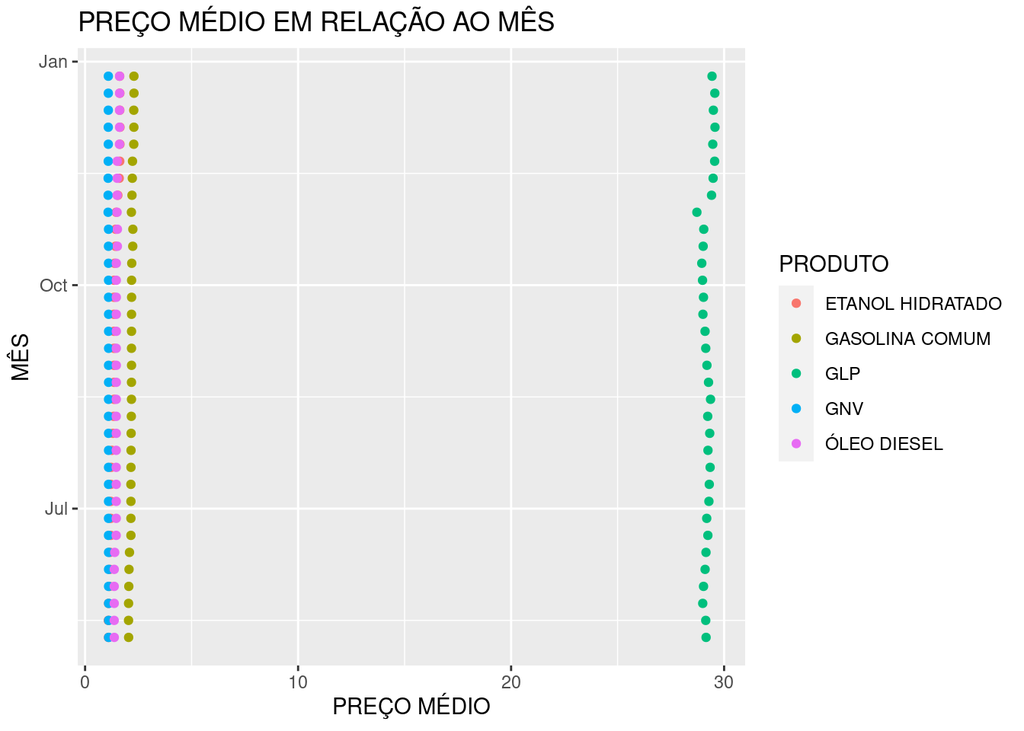

```r
anos_2004 %>%
  filter(ESTADO == 'RIO DE JANEIRO') %>%
  ggplot(aes(x = `PREÇO MÉDIO REVENDA`, y = `DATA INICIAL`, color = PRODUTO)) +
  geom_point() +
  labs(
      title = 'PREÇO MÉDIO EM RELAÇÃO AO MÊS',
      x = 'PREÇO MÉDIO',
      y = 'MÊS'
    )
```

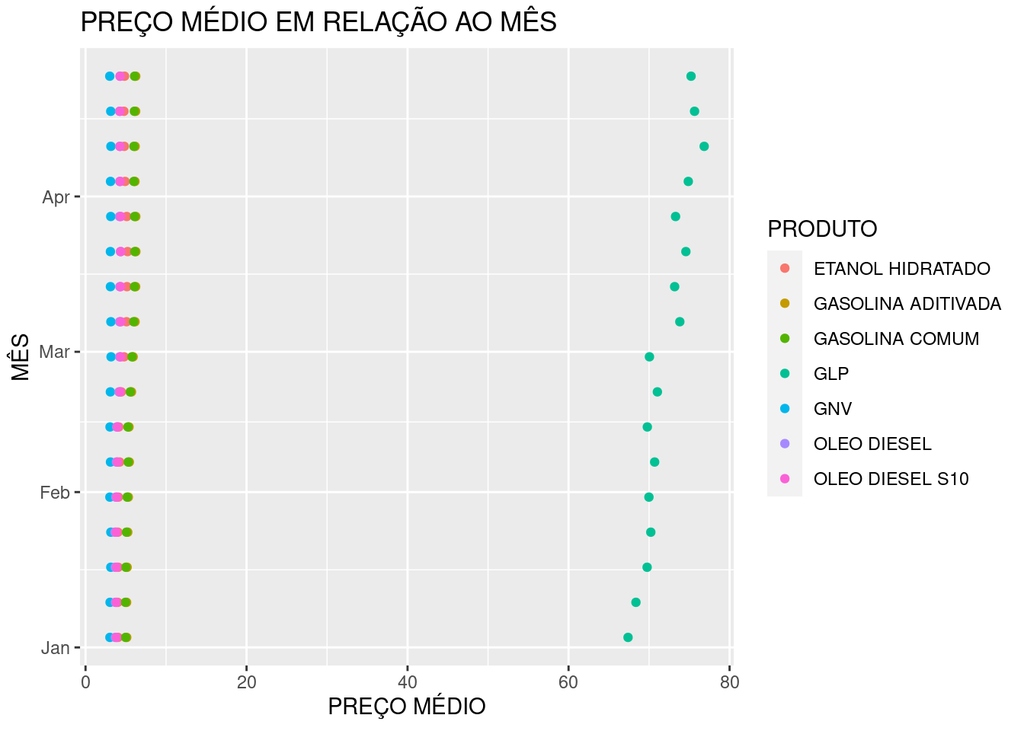

```r
anos_2021 %>%
  filter(ESTADO == 'RIO DE JANEIRO') %>%
  ggplot(aes(x = `PREÇO MÉDIO REVENDA`, y = `DATA INICIAL`, color = PRODUTO)) +
  geom_point() +
  labs(
      title = 'PREÇO MÉDIO EM RELAÇÃO AO MÊS',
      x = 'PREÇO MÉDIO',
      y = 'MÊS'
    )
```

## Histograma

- Número de postos pesquisados no Rio de Janeiro

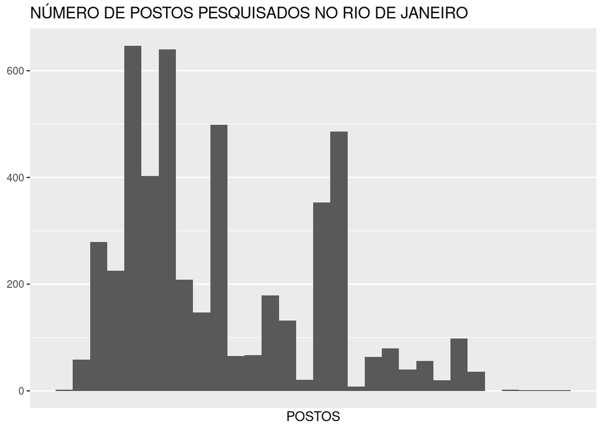

```r
combustivel_info %>%
  filter(ESTADO == 'RIO DE JANEIRO') %>%
  ggplot(aes(x = `NÚMERO DE POSTOS PESQUISADOS`)) +
    geom_histogram() +
  scale_x_continuous(breaks = seq(-100, 2000, 2000)) +
  labs(
    y = NULL,
    x = 'POSTOS',
    title = 'NÚMERO DE POSTOS PESQUISADOS NO RIO DE JANEIRO',
  )
```

## Boxplot

- Preço médio dos combustíveis automotivos do Brasil em 2004:

```r
# Removendo as linhas com "GLP" de um Data Frame
comb_auto_2004 <- anos_2004[!grepl("GLP",anos_2004$PRODUTO),]
comb_auto_2021 <- anos_2021[!grepl("GLP",anos_2021$PRODUTO),]

#Confirmando que as linhas do combustível GLP foram apagadas
comb_auto_2004%>%
  filter(PRODUTO == 'GLP')
```

```
## # A tibble: 0 × 5
## # … with 5 variables: DATA INICIAL <date>, ESTADO <chr>,
## #   PREÇO MÉDIO REVENDA <dbl>, PRODUTO <chr>, ANOS <dbl>
```

```r
comb_auto_2021%>%
  filter(PRODUTO == 'GLP')
```

```
## # A tibble: 0 × 5
## # … with 5 variables: DATA INICIAL <date>, ESTADO <chr>,
## #   PREÇO MÉDIO REVENDA <dbl>, PRODUTO <chr>, ANOS <dbl>
```

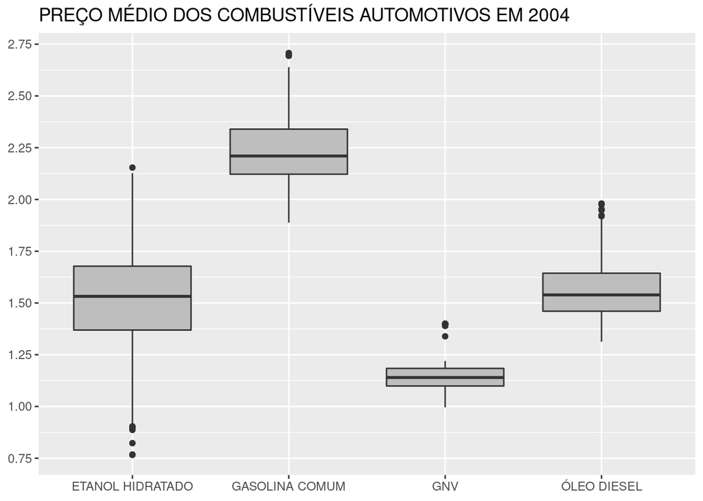

```r
boxp_2004 <- comb_auto_2004 %>%
  ggplot(aes(x = PRODUTO, y = `PREÇO MÉDIO REVENDA`)) +
  geom_boxplot(fill = 'gray') +
  scale_y_continuous(breaks = seq(0, 5, 0.25))+
  labs(
    title = "PREÇO MÉDIO DOS COMBUSTÍVEIS AUTOMOTIVOS EM 2004",
    x = NULL,
    y = NULL
  )
boxp_2004
```

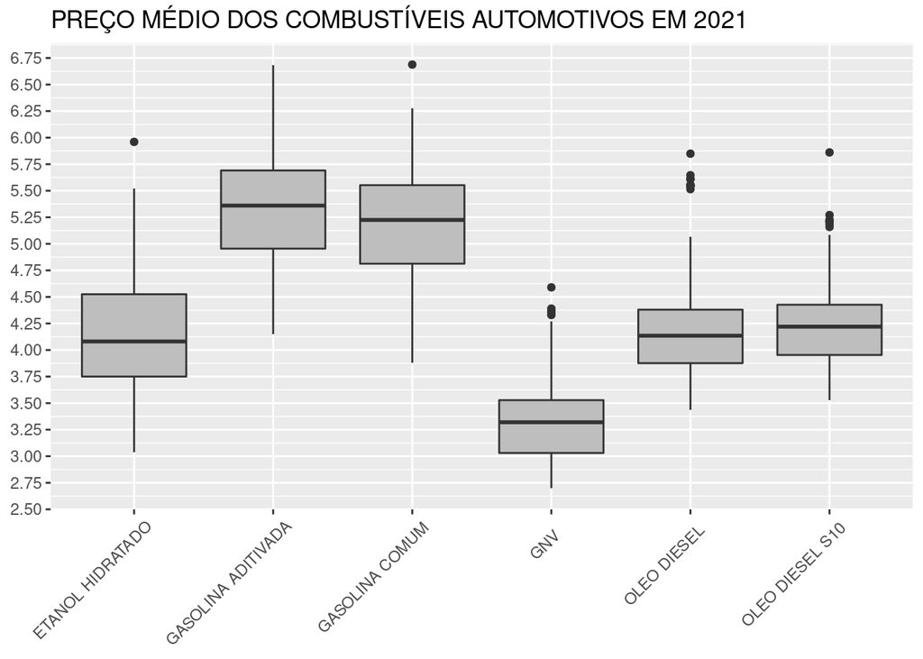

```r
boxp_2021 <- comb_auto_2021 %>%
  ggplot(aes(x = PRODUTO, y = `PREÇO MÉDIO REVENDA`)) +
  geom_boxplot(fill = 'gray') +
  scale_y_continuous(breaks = seq(0, 10, 0.25))+
  labs(
    title = "PREÇO MÉDIO DOS COMBUSTÍVEIS AUTOMOTIVOS EM 2021",
    x = NULL,
    y = NULL
  )

boxp_2021 +
  theme(
    axis.text.x = element_text(
      angle = 45,
      vjust = .9,
      hjust = .9
    )
  )
```

## Barra e colunas

- Frequência da análise dos combustíveis em cada região do Brasil.

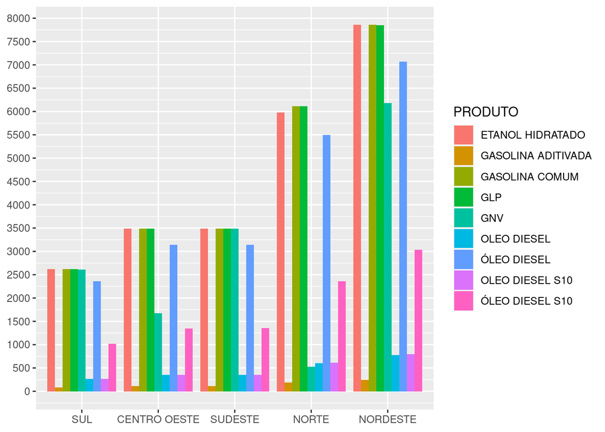

```r
combustivel_info %>%
  ggplot(aes(x = fct_rev(fct_infreq(REGIÃO)), fill = PRODUTO)) +
    geom_bar(position = 'dodge') +
    labs(
      x = NULL,
      y = NULL
    ) +
    scale_y_continuous(breaks = seq(0, 8000, 500))
```

- Experimentando uma paleta de cores diferente:

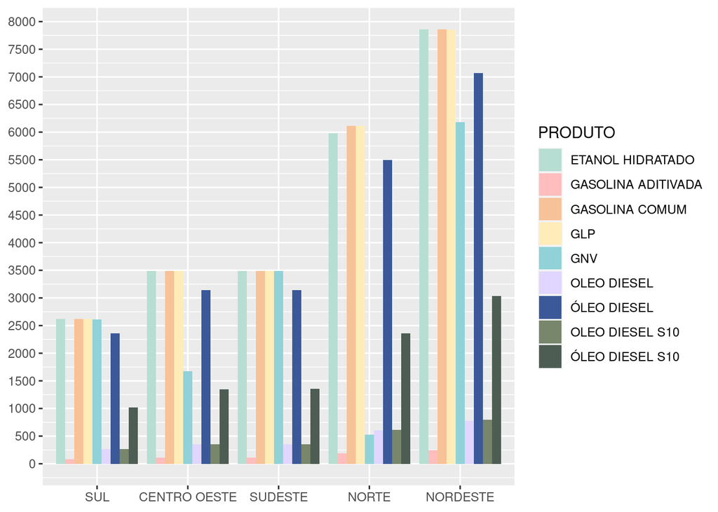

```r
combustivel_info %>%
  ggplot(aes(x = fct_rev(fct_infreq(REGIÃO)), fill = PRODUTO)) +
    geom_bar(position = 'dodge') +
    labs(
      x = NULL,
      y = NULL
    ) +
    scale_y_continuous(breaks = seq(0, 8000, 500)) +
    scale_fill_discrete(
      type = c('#b7ded2', '#ffbdbd', '#f7c297', '#ffecb8', '#90d2d8', '#e0d6ff', '#3b5998', '#78866b', '#4d5d53')
    )
```

## Gráfico de linha

- Número de postos pesquisados em cada região do Brasil (2004-2021):

```r
# Criando uma tibble com as colunas ANO, REGIÃO e NÚMERO DE POSTOS
DATAS <- combustivel_info['DATA INICIAL']
NUM_POSTOS <- combustivel_info['NÚMERO DE POSTOS PESQUISADOS']
REG <- combustivel_info['REGIÃO']

for (elem in DATAS)
{
  ANO <- year(elem)
}

postos_info <- tibble(ANO, REG, NUM_POSTOS)
postos_info
```

```
## # A tibble: 120,823 × 3
##      ANO REGIÃO       `NÚMERO DE POSTOS PESQUISADOS`
##    <dbl> <chr>                                 <dbl>
##  1  2004 CENTRO OESTE                            127
##  2  2004 CENTRO OESTE                            387
##  3  2004 CENTRO OESTE                            192
##  4  2004 CENTRO OESTE                            162
##  5  2004 NORDESTE                                103
##  6  2004 NORDESTE                                408
##  7  2004 NORDESTE                                278
##  8  2004 NORDESTE                                105
##  9  2004 NORDESTE                                125
## 10  2004 NORDESTE                                423
## # … with 120,813 more rows
```

```r
# Usando a função aggregate para somar, por região, todos os postos pesquisados em cada ano
postos_info = aggregate(x = postos_info$`NÚMERO DE POSTOS PESQUISADOS`, by = list(postos_info$ANO, postos_info$REGIÃO), FUN = "sum")

postos_info
```

```
##    Group.1      Group.2       x
## 1     2004 CENTRO OESTE  113422
## 2     2005 CENTRO OESTE  158848
## 3     2006 CENTRO OESTE  192283
## 4     2007 CENTRO OESTE  146751
## 5     2008 CENTRO OESTE  144664
## 6     2009 CENTRO OESTE  128627
## 7     2010 CENTRO OESTE  139416
## 8     2011 CENTRO OESTE  142065
## 9     2012 CENTRO OESTE  143956
## 10    2013 CENTRO OESTE  147170
## 11    2014 CENTRO OESTE  151542
## 12    2015 CENTRO OESTE  126176
## 13    2016 CENTRO OESTE  115225
## 14    2017 CENTRO OESTE   98409
```

[output cut: 76 more lines]

```r
# Renomeando as colunas
colnames(postos_info) <- c("ANO", "REGIÃO", "NÚMERO DE POSTOS")
postos_info
```

```
##     ANO       REGIÃO NÚMERO DE POSTOS
## 1  2004 CENTRO OESTE           113422
## 2  2005 CENTRO OESTE           158848
## 3  2006 CENTRO OESTE           192283
## 4  2007 CENTRO OESTE           146751
## 5  2008 CENTRO OESTE           144664
## 6  2009 CENTRO OESTE           128627
## 7  2010 CENTRO OESTE           139416
## 8  2011 CENTRO OESTE           142065
## 9  2012 CENTRO OESTE           143956
## 10 2013 CENTRO OESTE           147170
## 11 2014 CENTRO OESTE           151542
## 12 2015 CENTRO OESTE           126176
## 13 2016 CENTRO OESTE           115225
## 14 2017 CENTRO OESTE            98409
```

[output cut: 76 more lines]

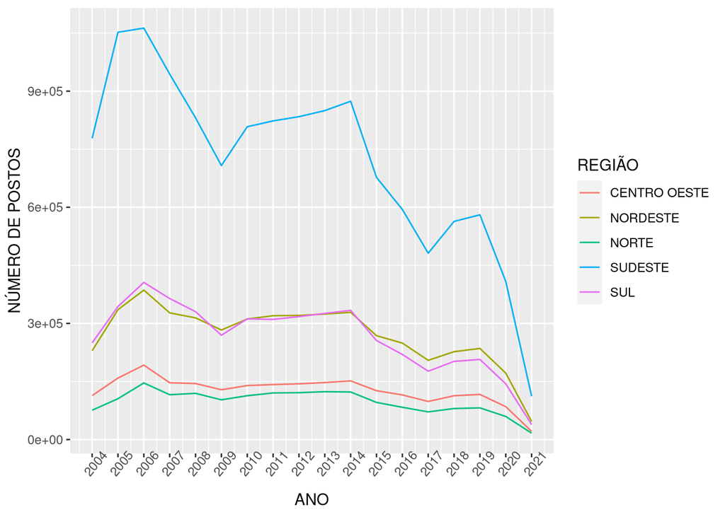

```r
# Criando o gráfico
postos_info %>%
  ggplot(aes(x = ANO, y = `NÚMERO DE POSTOS`, color = REGIÃO)) +
    geom_line() +
    scale_x_continuous(breaks = 2004:2021) +
    theme(axis.text.x = element_text(angle = 50))
```

```r
    labs(
      y = "POSTOS PESQUISADOS",
      x = "ANOS"
    )
```

```
## $y
## [1] "POSTOS PESQUISADOS"
##
## $x
## [1] "ANOS"
##
## attr(,"class")
## [1] "labels"
```

- **9e+05* = 9*10^5 = 900.000**

# Bibliografia

- [R is.na Function Example (remove, replace, count, if else, is not NA)](https://statisticsglobe.com/r-is-na-function/)
- [Ciência de Dados com R - Manipulando os dados](https://cdr.ibpad.com.br/manipulando-os-dados.html)
- [Ciência de Dados com R - Trabalhando com datas](http://sillasgonzaga.com/material/cdr/trabalhando-com-datas.html)
- [Como excluir linhas de DATAFRAME R com base na correspondência de Strings?](https://acervolima.com/como-excluir-linhas-de-dataframe-r-com-base-na-correspondencia-de-string/)
- [Remova linhas duplicadas por coluna em R](https://www.delftstack.com/pt/howto/r/remove-duplicates-in-r/)
- [Como alterar o nome de uma coluna?](https://pt.stackoverflow.com/questions/126900/como-alterar-o-nome-de-uma-coluna)
- [Aggregate in R](https://r-coder.com/aggregate-r/)